# FBI Crime Data from 1997 - Present

Kimberly Mincin

# Front Matter

```r
rm(list = ls())
library(DataComputing)
library(mosaic)
library(readxl)
library(tidyr)
library(party)
```

## Reading in the Data

```r
FBI_year_original <- read_excel("C:\\Users\\minci\\Downloads\\FBI Data.xls")
View(FBI_year_original)
```

## Cleaning the Data

```r
FBI_year <-
  FBI_year_original %>%
  filter(row_number()>3)%>%
  filter(row_number()< 21)
View(FBI_year)
names(FBI_year) <- c("year", "population", "violent crimes", "violent crime rate", "murder and nonnegligent manslaughter", "murder and nonnegligent manslaughter rate", "revised definition", "revised definition rate", "legacy definition", "legacy definition rate", "robbery", "robbery rate", "aggravated assault", "aggravted assault rate", "property crime", "property crime rate", "burglary", "burglary rate", "larceny-theft", "larceny-theft rate", "motor vehicle theft", "motor vehicle theft rate")
```

```r
FBI_year <-
  FBI_year%>%
  gather(key=`rape definition`, value=rape, `revised definition`, `legacy definition`)
```

```r
FBI <-
  FBI_year%>%
  select(year, population, `violent crimes`, `murder and nonnegligent manslaughter`, robbery, `aggravated assault`, `property crime`, burglary, `larceny-theft`,`motor vehicle theft`, `rape definition`, rape)
View(FBI)
glimpse(FBI)
```

```
Observations: 40
Variables: 12
$ year                                   <chr> "1997", "1998", "1999", "2000", "2001", "2002", "2003",...
$ population                             <chr> "267783607", "270248003", "272690813", "281421906", "28...
$ `violent crimes`                       <chr> "1636096", "1533887", "1426044", "1425486", "1439480", ...
$ `murder and nonnegligent manslaughter` <chr> "18208", "16974", "15522", "15586", "16037", "16229", "...
$ robbery                                <chr> "498534", "447186", "409371", "408016", "423557", "4208...
$ `aggravated assault`                   <chr> "1023201", "976583", "911740", "911706", "909023", "891...
$ `property crime`                       <chr> "11558475", "10951827", "10208334", "10182584", "104371...
$ burglary                               <chr> "2460526", "2332735", "2100739", "2050992", "2116531", ...
$ `larceny-theft`                        <chr> "7743760", "7376311", "6955520", "6971590", "7092267", ...
$ `motor vehicle theft`                  <chr> "1354189", "1242781", "1152075", "1160002", "1228391", ...
$ `rape definition`                      <chr> "revised definition", "revised definition", "revised de...
$ rape                                   <chr> NA, NA, NA, NA, NA, NA, NA, NA, NA, NA, NA, NA, NA, NA,...
```

# Analysis

The first thing I wanted to see was how the rate of violent crimes changed over time. Surprisingly the graph below depicts violent crime rate primarily decreasing over time.

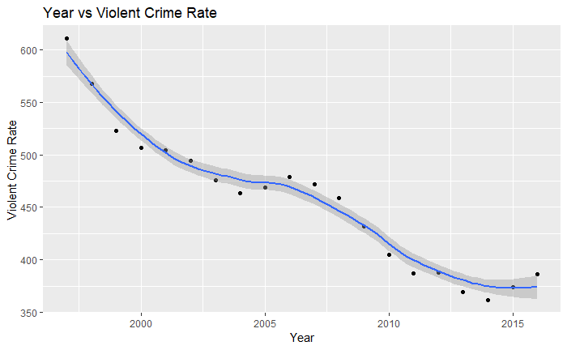

```r
FBI_year%>%
  ggplot(aes(x=as.numeric(year), y=as.numeric(`violent crime rate`)))+
  geom_point()+
  stat_smooth()+
  ggtitle("Year vs Violent Crime Rate")+
  ylab("Violent Crime Rate")+
  xlab("Year")
```

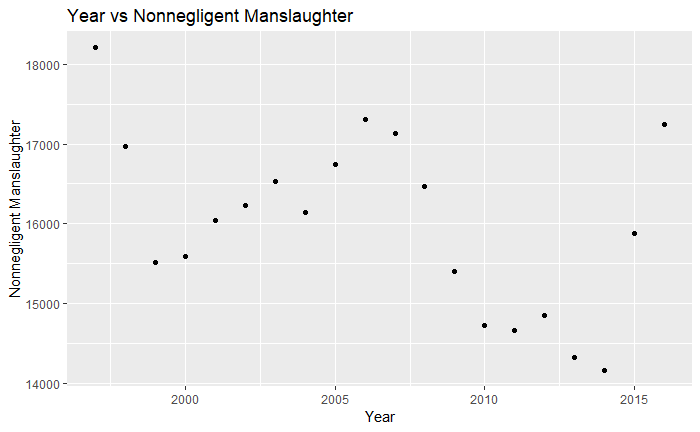

```r
FBI_year%>%
  ggplot(aes(x=as.numeric(year), y=as.numeric(`murder and nonnegligent manslaughter`)))+
  geom_point()+
  ggtitle("Year vs Nonnegligent Manslaughter")+
  ylab("Nonnegligent Manslaughter")+
  xlab("Year")
```

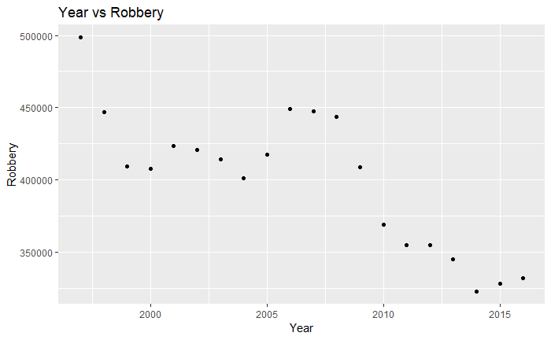

```r
FBI_year%>%
  ggplot(aes(x=as.numeric(year), y=as.numeric(robbery)))+
  geom_point()+
  ggtitle("Year vs Robbery")+
  ylab("Robbery")+
  xlab("Year")
```

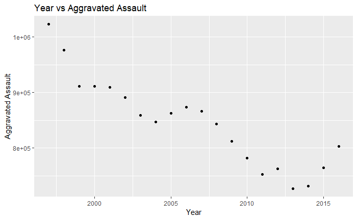

```r
FBI_year%>%
  ggplot(aes(as.numeric(x=year), y=as.numeric(`aggravated assault`)))+
  geom_point()+
  ggtitle("Year vs Aggravated Assault")+
  ylab("Aggravated Assault")+
  xlab("Year")
```

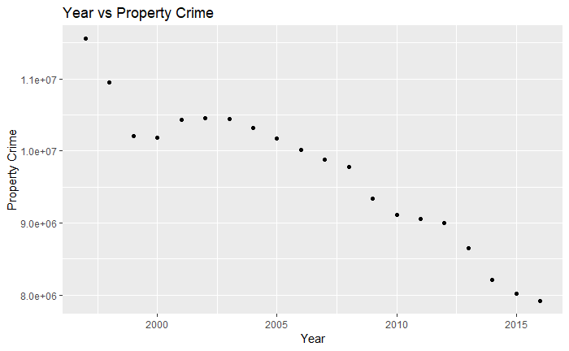

```r
FBI_year%>%
  ggplot(aes(as.numeric(x=year), y=as.numeric(`property crime`)))+
  geom_point()+
  ggtitle("Year vs Property Crime")+
  ylab("Property Crime")+
  xlab("Year")
```

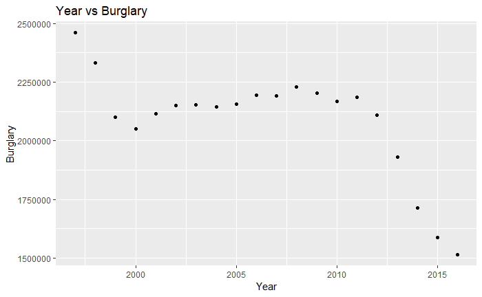

```r
FBI_year%>%
  ggplot(aes(as.numeric(x=year), y=as.numeric(burglary)))+
  geom_point()+
  ggtitle("Year vs Burglary")+
  ylab("Burglary")+
  xlab("Year")
```

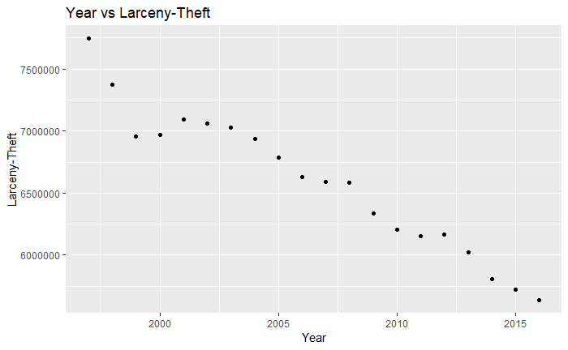

```r
FBI_year%>%
  ggplot(aes(x=as.numeric(year), y=as.numeric(`larceny-theft`)))+
  geom_point()+
  ggtitle("Year vs Larceny-Theft")+
  ylab("Larceny-Theft")+
  xlab("Year")
```

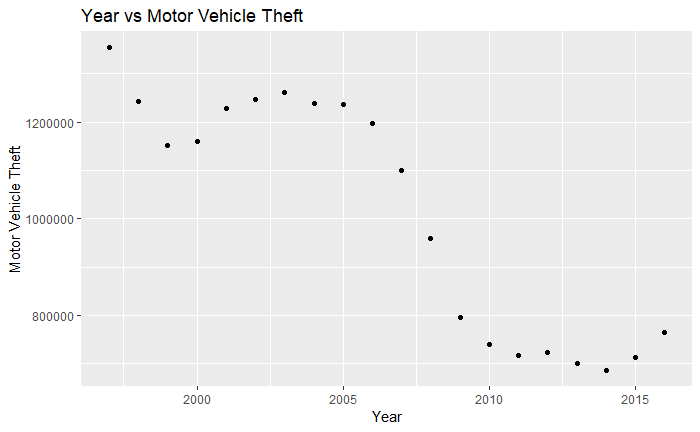

```r
FBI_year%>%
  ggplot(aes(x=as.numeric(year), y=as.numeric(`motor vehicle theft`)))+
  geom_point()+
  ggtitle("Year vs Motor Vehicle Theft")+
  ylab("Motor Vehicle Theft")+
  xlab("Year")
```

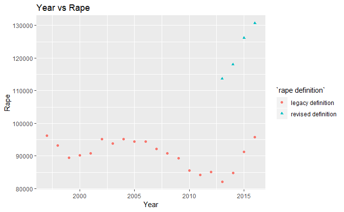

```r
FBI_year%>%
  ggplot(aes(x=as.numeric(year), y=as.numeric(rape), color=`rape definition`))+
  geom_point(aes(shape=`rape definition`))+
  ggtitle("Year vs Rape")+
  ylab("Rape")+
  xlab("Year")
```

In order to figure out the best predictor of violent crimes I created a tree using the different types of crime. The best and only statistically significant predictor of violent crime was aggravated assault. I am not surprised that aggravated assault is the best predictor for the number of violent crimes since it’s graph most closely matches that of violent crimes. However I am surprised that it is the only significant variable for predictiong the number of violent crimes.

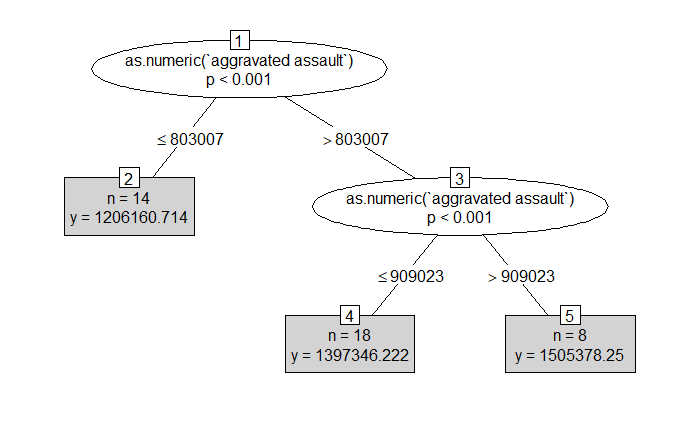

```r
mod1 <- party::ctree(as.numeric(`violent crimes`) ~ as.numeric(`murder and nonnegligent manslaughter`) + as.numeric(robbery) + as.numeric(`aggravated assault`) + as.numeric(burglary) + as.numeric(`larceny-theft`) + as.numeric(`motor vehicle theft`) + as.numeric(rape), data=FBI)
plot(mod1, type="simple")
```